# Unit 12

Chad Madding

March 18, 2020

## Multiple Regression with Correlated Errors

In the following R code, y denotes the realization Y_t, z denotes Z_t, and x1,…, xm denote Xt_1,…,X_tm

**Step 1:** Perform a regression analysis and model the residuals (should be uncorrelated and normal distributed). The following is example code (with m=3):

```r
#ksfit=lm(y~x1+x2+x3)
#phi=aic.wge(ksfit$residuals,p=0:8)
```

**Step 2:** Use function ARIMA to perform the MLE analysis which estimates the coefficients in the multiple regression while simultaneously modeling Z_t as AR(phi$p)

```r
#fit=arima(sales,order=c(p=phi$p,d=0,q=0),xreg=cbind(x1,x2,x3))
```

**fit$coef** contains the AR coefficients, the constant, and the coefficients on x1, x2, and x3

The command

**fit** produces the following example dummy output (assuming phi$p=2)

```
Coefficients:
      ar1      ar2   intercept    x1     x2     x3
      1.6     -0.8    10.5       2.3    3.1    0.3
s.e.  0.6      0.3     2.2       0.9    1.2    0.2
sigma2 estimated as 1.4: log likelihood=-16,aic=20.1
```

- Recall that we don’t usually look at the SE’s for AR and MA coefficients (the factor table gives more information).
- Function arima doesn’t give p-values, but in general if the absolute value of the coefficient is over two times the SE, this is evidence at the .05 level that the variable is useful.
- The final model residuals are given in **fit$resid**, and they should be white
  - Check with residual plots and/or **Ljung-Box Test**.
- Compare competing models with **AIC/AIC/BIC** etc.
- Use the model to forecast and/or answer any additional Questions Of Interest (QOI’s).

## Sales Example

We are interested identifying variables that impact sales (Y).  
Variables we consider are (data in file BusinessSales.csv)  
*TV advertising expenditures (_1) (variable ad_tv) *Online advertising expenditures (_2) (ad_online) *Discount on product (_3) (variable discount)

We have data for the past 100 weeks. That is, for each variable, we have a time series realization of length n =100 (weeks):

```
sales:  (x $10,000)
ad_tv:  (x $10,000)
ad_online:  (x $10,000)
discount:  (% discount)
```

**Output time series multiple regression analysis**

```
## $type
## [1] "aic"
##
## $value
## [1] 1.101655
##
## $p
## [1] 7
##
## $q
## [1] 0
##
## $phi
## [1]  0.3914830668  0.1263257053 -0.3764190275 -0.0005409533  0.1006855558
## [6]  0.2148095958  0.1476114131
##
## $theta
## [1] 0
##
## $vara
## [1] 2.564221
```

```
##
## Call:
## arima(x = BSales$sales, order = c(7, 0, 0), xreg = BSales[, 3:5])
##
## Coefficients:
##          ar1      ar2     ar3     ar4     ar5     ar6      ar7  intercept
##       1.4734  -0.8921  0.0749  0.0919  0.0438  0.1865  -0.1287    54.5513
## s.e.  0.1107   0.1963  0.2167  0.2057  0.2049  0.1852   0.1080     2.2040
##        ad_tv  ad_online  discount
##       0.0703    -0.0934   -0.1514
## s.e.  0.3434     0.2075    0.1315
##
## sigma^2 estimated as 1.411:  log likelihood = -161.1,  aic = 346.21
```

**Multiple regression equation**
$$sales=54.55+.07(ad_{tv})-.09(online_{ad})-.15(discount)$$

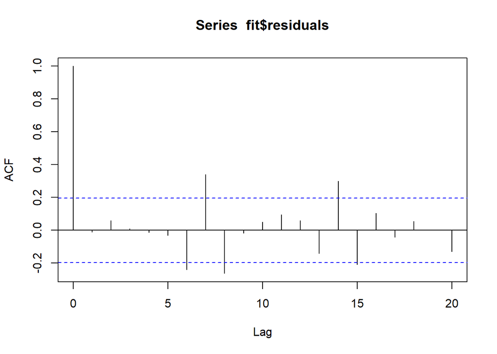

```r
acf(fit$residuals)
```

```r
#run the Ljung_Box Test
ltest = ljung.wge(fit$resid)
```

```
## Obs -0.01040185 0.05898301 0.008929627 -0.01224377 -0.0296057 -0.2398486 0.3402942 -0.2623472 -0.01792799 0.04983832 0.09440642 0.05862074 -0.1409925 0.299757 -0.208223 0.1039675 -0.04145994 0.05483977 0.002771559 -0.1299524 0.228699 -0.1645907 0.09479325 -0.170837
```

```r
#One way to Disable Scientific Notation
format(ltest$pval, scientific = FALSE)
```

```
## [1] "0.000007445469"
```

There is strong evidence that the residuals are serially correlated.

ASE for model with no lag and no trend (last 5)

```r
# ASE for model with no lag and no trend (last 5)
BSales2 = BSales[1:95,]
ksfit=lm(sales~ad_tv+ad_online+discount, data = BSales2)
aic.wge(ksfit$residuals,p=0:8, q=0)  # AIC picks p=7
```

```
## $type
## [1] "aic"
##
## $value
## [1] 1.119875
##
## $p
## [1] 7
##
## $q
## [1] 0
##
## $phi
## [1]  0.39110624  0.13440258 -0.39244949  0.03048536  0.07647737  0.19178372
## [7]  0.16884555
##
## $theta
## [1] 0
##
## $vara
## [1] 2.589471
```

```r
fit=arima(BSales2$sales,order=c(7,0,0),xreg=cbind(BSales2$ad_tv,BSales2$ad_online,BSales2$discount))
fit
```

```
##
## Call:
## arima(x = BSales2$sales, order = c(7, 0, 0), xreg = cbind(BSales2$ad_tv, BSales2$ad_online,
##     BSales2$discount))
##
## Coefficients:
##          ar1      ar2     ar3    ar4     ar5     ar6      ar7  intercept
##       1.4819  -0.9000  0.1156  0.073  0.0122  0.2405  -0.1444    55.5453
## s.e.  0.1129   0.2002  0.2214  0.213  0.2141  0.1924   0.1106     2.3458
##       cbind(BSales2$ad_tv, BSales2$ad_online, BSales2$discount)1
##                                                          -0.0418
## s.e.                                                      0.3508
##       cbind(BSales2$ad_tv, BSales2$ad_online, BSales2$discount)2
##                                                          -0.1579
## s.e.                                                      0.2143
##       cbind(BSales2$ad_tv, BSales2$ad_online, BSales2$discount)3
##                                                          -0.1140
## s.e.                                                      0.1489
##
## sigma^2 estimated as 1.426:  log likelihood = -153.65,  aic = 331.29
```

- The errors in the standard multiple regression satisfy an AR(7) and are correlated
- None of the variables ad_tv, ad_online, or discount are significantly different from zero
- The final model residuals are not white (fit$resid)

```r
preds = predict(fit, newxreg = cbind(BSales$ad_tv[96:100],BSales$ad_online[96:100],BSales$discount[96:100]))
ASE1 = mean((BSales$sales[96:100] - preds$pred)^2)
ASE1
```

```
## [1] 57.1069
```

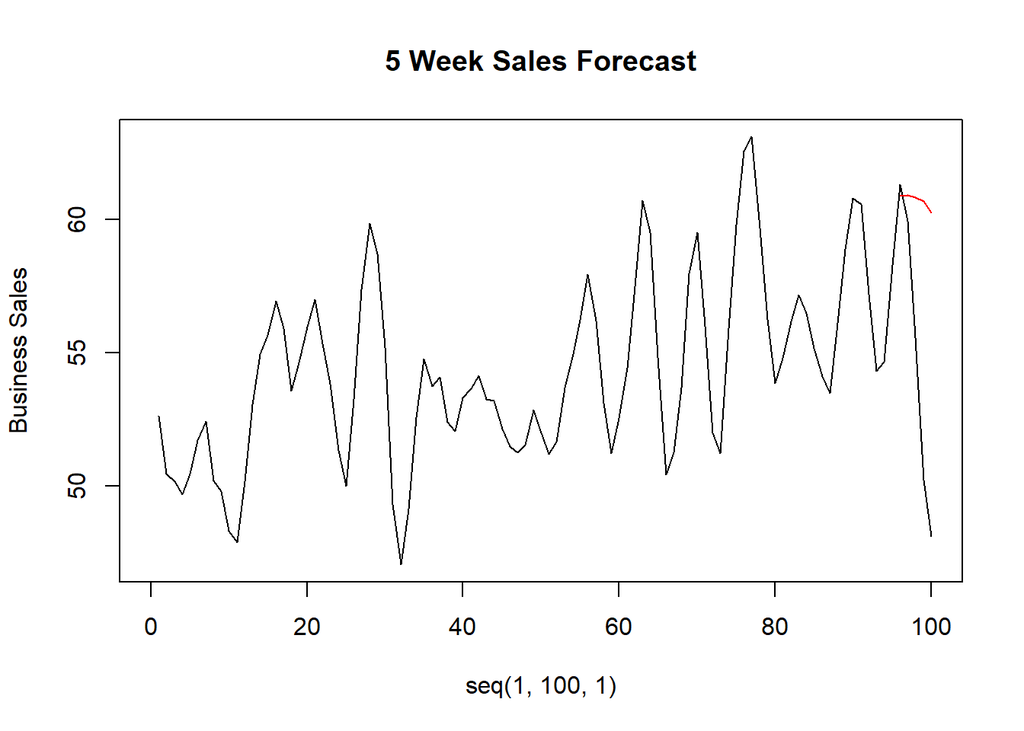

```r
#dev.off()
plot(seq(1,100,1), BSales$sales[1:100], type = "l",xlim = c(0,100), ylab = "Business Sales", main = "5 Week Sales Forecast")
lines(seq(96,100,1), preds$pred, type = "l", col = "red")
```

These results are not very enlightening (or encouraging)

Let’s try adding a trend term to the model

## Add a trend term (t=week) to the model

```r
t=1:100
ksfit=lm(sales~t+ad_tv+ad_online+discount, data = BSales)
aic.wge(ksfit$residuals,p=0:8,q=0:0)  # AIC picks p=6
```

```
## $type
## [1] "aic"
##
## $value
## [1] 0.9835036
##
## $p
## [1] 6
##
## $q
## [1] 0
##
## $phi
## [1]  0.44043768  0.06888471 -0.42345549 -0.05290844  0.08724326  0.21222750
##
## $theta
## [1] 0
##
## $vara
## [1] 2.324497
```

```r
fit=arima(BSales$sales,order=c(6,0,0),xreg=cbind(t,BSales[,3:5]))
fit
```

```
##
## Call:
## arima(x = BSales$sales, order = c(6, 0, 0), xreg = cbind(t, BSales[, 3:5]))
##
## Coefficients:
##          ar1      ar2     ar3     ar4     ar5      ar6  intercept       t
##       1.4090  -0.8778  0.0180  0.0562  0.1676  -0.0364    51.9224  0.0465
## s.e.  0.1131   0.1978  0.2182  0.2057  0.1785   0.1050     2.2242  0.0148
##        ad_tv  ad_online  discount
##       0.1123    -0.0508   -0.1701
## s.e.  0.3549     0.1939    0.1052
##
## sigma^2 estimated as 1.363:  log likelihood = -159.14,  aic = 342.29
```

**time (week) is significant, other variables are not**

**Multiple regression equation**
$$sales=51.92+.05(week)+.11(ad_{tv})-.05(online_{ad})-.17(discount)$$

- Again the errors in the standard multiple regression satisfy an AR(6) and are correlated
- Time was significant (with positive slope) so it seems that sales are increasing with time
- None of the variables ad_tv, ad_online, or discount are significantly different from zero
- The final model residuals are not white

**Summary:**

Let’s keep working on this!

#### How About Using Lagged Variables?

Advertising for the week didn’t seem to predict sales for that week

- It could be that advertising has a lag effect
- That is, advertising for the current week may have more effect on sales next week than this week

We next considered a multiple regression in which the advertising variables at time t are actually costs for the previous week

- These will be denoted **ad_tv1** and **ad_online1**
- The new variables will be
  - ad_tv1[t]=ad_tv[t-1]
  - ad_online1[t]=ad_online[t-1]

**Example:** How to create lagged variables in R

```r
#Explicitly
#Example:
#With dplyr lag function
df = data.frame(Y = c(1,1,2,3,4,4,5,8),X1 = c(5,6,6,7,7,8,8,9))
df$X1_L1 = dplyr::lag(df$X1,1)
df$X1_L2 = dplyr::lag(df$X1,2)
df
```

```
##   Y X1 X1_L1 X1_L2
## 1 1  5    NA    NA
## 2 1  6     5    NA
## 3 2  6     6     5
## 4 3  7     6     6
## 5 4  7     7     6
## 6 4  8     7     7
## 7 5  8     8     7
## 8 8  9     8     8
```

#### 12.2.5 Consept Check

Using sales data set, use R to lag (k = 1) the TV Advertising and Online Advertising data.  
Add those lagged columns to the Business data frame.

```r
ad_tv1 = dplyr::lag(BSales$ad_tv,1)
ad_online1 = dplyr::lag(BSales$ad_online,1)
discount = BSales$discount
BSales$ad_tv1= ad_tv1
BSales$ad_online1 = ad_online1
head(BSales)
```

```
##   X    sales    ad_tv ad_online  discount   ad_tv1 ad_online1
## 1 1 52.61137 5.105617  3.646744 0.0000000       NA         NA
## 2 2 50.46478 5.233105  3.381140 0.0000000 5.105617   3.646744
## 3 3 50.15374 5.202212  3.550546 0.7571115 5.233105   3.381140
## 4 4 49.68254 5.386699  3.570285 3.5303790 5.202212   3.550546
## 5 5 50.44613 4.961060  3.460531 5.4983130 5.386699   3.570285
## 6 6 51.72145 5.153207  3.801946 7.2211060 4.961060   3.460531
```

```r
ksfit=lm(sales~ad_tv1+ad_online1+discount, data = BSales)
aic.wge(ksfit$residuals,p=0:8,q=0:0)  # AIC picks p=7
```

```
## $type
## [1] "aic"
##
## $value
## [1] 0.7481867
##
## $p
## [1] 7
##
## $q
## [1] 0
##
## $phi
## [1] -0.06461833  0.19212542 -0.08348717 -0.01488629 -0.13475021  0.23864863
## [7]  0.18607832
##
## $theta
## [1] 0
##
## $vara
## [1] 1.797812
```

```r
fit=arima(BSales$sales,order=c(7,0,0),xreg=cbind(ad_tv1, ad_online1, discount))
fit
```

```
##
## Call:
## arima(x = BSales$sales, order = c(7, 0, 0), xreg = cbind(ad_tv1, ad_online1,
##     discount))
##
## Coefficients:
##           ar1     ar2      ar3      ar4      ar5      ar6     ar7  intercept
##       -0.5197  0.1348  -0.0787  -0.1155  -0.1954  -0.0004  0.0485     4.8382
## s.e.   0.1839  0.1689   0.1233   0.1256   0.1309   0.1884  0.1574     2.8270
##       ad_tv1  ad_online1  discount
##       3.4341      8.1152   -0.0573
## s.e.  0.6166      1.2447    0.0281
##
## sigma^2 estimated as 1.642:  log likelihood = -165.43,  aic = 354.86
```

#### 12.3 Multivariate Regression with Correlated Errors, Part II

Generate lagged variables.

```r
ad_tv1 = dplyr::lag(BSales$ad_tv,1)
ad_online1 = dplyr::lag(BSales$ad_online,1)
discount = BSales$discount
BSales$ad_tv1= ad_tv1
BSales$ad_online1 = ad_online1
head(BSales)
```

```
##   X    sales    ad_tv ad_online  discount   ad_tv1 ad_online1
## 1 1 52.61137 5.105617  3.646744 0.0000000       NA         NA
## 2 2 50.46478 5.233105  3.381140 0.0000000 5.105617   3.646744
## 3 3 50.15374 5.202212  3.550546 0.7571115 5.233105   3.381140
## 4 4 49.68254 5.386699  3.570285 3.5303790 5.202212   3.550546
## 5 5 50.44613 4.961060  3.460531 5.4983130 5.386699   3.570285
## 6 6 51.72145 5.153207  3.801946 7.2211060 4.961060   3.460531
```

Fit the lagged variables with a Multivariate regression.

```r
ksfit=lm(sales~ad_tv1+ad_online1+discount, data = BSales)
aic.wge(ksfit$residuals,p=0:8,q=0:0)  # AIC picks p=7
```

```
## $type
## [1] "aic"
##
## $value
## [1] 0.7481867
##
## $p
## [1] 7
##
## $q
## [1] 0
##
## $phi
## [1] -0.06461833  0.19212542 -0.08348717 -0.01488629 -0.13475021  0.23864863
## [7]  0.18607832
##
## $theta
## [1] 0
##
## $vara
## [1] 1.797812
```

```r
#Fit using the AIC information
fit=arima(BSales$sales,order=c(7,0,0),xreg=cbind(ad_tv1, ad_online1, discount))
fit
```

```
##
## Call:
## arima(x = BSales$sales, order = c(7, 0, 0), xreg = cbind(ad_tv1, ad_online1,
##     discount))
##
## Coefficients:
##           ar1     ar2      ar3      ar4      ar5      ar6     ar7  intercept
##       -0.5197  0.1348  -0.0787  -0.1155  -0.1954  -0.0004  0.0485     4.8382
## s.e.   0.1839  0.1689   0.1233   0.1256   0.1309   0.1884  0.1574     2.8270
##       ad_tv1  ad_online1  discount
##       3.4341      8.1152   -0.0573
## s.e.  0.6166      1.2447    0.0281
##
## sigma^2 estimated as 1.642:  log likelihood = -165.43,  aic = 354.86
```

both ad variables are highly significant.  
3.43/.6 and 8.1/1.24. Far away from zero and larger standard error.

Now let look at adding a time trend.

```r
t=1:100
ad_tv1 = dplyr::lag(BSales$ad_tv,1)
ad_online1 = dplyr::lag(BSales$ad_online,1)
BSales$ad_tv1= ad_tv1
BSales$ad_online1 = ad_online1

#fit the model
ksfit=lm(sales~t + ad_tv1+ad_online1+discount, data = BSales)
aic.wge(ksfit$residuals,p=0:8,q=0:0)  # AIC picks p=7
```

```
## $type
## [1] "aic"
##
## $value
## [1] 0.7031507
##
## $p
## [1] 7
##
## $q
## [1] 0
##
## $phi
## [1] -0.05644526  0.15653543 -0.12479280 -0.05005342 -0.14801128  0.23402135
## [7]  0.16170821
##
## $theta
## [1] 0
##
## $vara
## [1] 1.718642
```

```r
fit=arima(BSales$sales,order=c(7,0,0),xreg=cbind(t, ad_tv1, ad_online1, discount)) #sales is the responce variable
fit
```

```
##
## Call:
## arima(x = BSales$sales, order = c(7, 0, 0), xreg = cbind(t, ad_tv1, ad_online1,
##     discount))
##
## Coefficients:
##           ar1     ar2      ar3      ar4      ar5     ar6     ar7  intercept
##       -0.5062  0.1265  -0.1053  -0.1388  -0.1985  0.0109  0.0493     6.2215
## s.e.   0.1883  0.1537   0.1138   0.1160   0.1206  0.1805  0.1535     2.7820
##            t  ad_tv1  ad_online1  discount
##       0.0065  3.3180      7.8248   -0.0453
## s.e.  0.0038  0.6288      1.3020    0.0276
##
## sigma^2 estimated as 1.577:  log likelihood = -163.43,  aic = 352.87
```

The AIC is lower in the model with the Time trend so the AIC favors the one with trend.

**Lagged “ad” variables and trend:**

$$Sales=\beta_0+\beta_{1t}+\beta_2ad_tv_{t-1}+\beta_3ad_online{t_1}+\beta_4discount_t+Z_t\ Z_t\ is\ AR(7)$$

Time is somewhat significant, around 2 if we divide (.0065/.0038=1.71). The two ad’s are still very significant, and the discount is not significant.

**Results:**

- Again, the errors in the standard multiple regression are correlated so we used an AR(7).
- Discount was not significant with or without trend in the model.
- Lagged variables **ad_tv1** and **ad_online1** were highly significant.
- In the presence of the lagged variables, time (trend) was not significant (although favored by AIC).
- The final model residuals (with trend) are white:

```r
ltest = ljung.wge(fit$resid)
```

```
## Obs -0.009293452 0.01646604 0.02894965 -0.009869615 -0.01486158 -0.02946822 0.1226944 0.04645335 -0.1633533 0.008771068 0.05078351 0.04415603 -0.1225541 -0.02715931 -0.06323245 -0.03191085 -0.1456455 0.03885317 0.03548764 -0.017886 0.10873 -0.1126548 -0.05994556 -0.204109
```

```r
ltest$pval
```

```
## [1] 0.6758827
```

There is not enough evidence to suggest that the residuals are serially correlated.

**Summary:**  
Advertising effects seem to be delayed

The preceding example makes an important point regarding lagged variables in multiple regression.

$$Y_t=\beta_1X_{t1}+\beta_2X_{t2}+...+\beta_mX_{tm}+Z_t$$

**Note from the model:**  
* All independent variables and the dependent variable are evaluated at the same time$t$.  
+ This restriction seems to eliminate the use of lagged relationships in the multiple regression model.  
* However, using the technique employed in the sales example, you can let, for example,$X_{t1}$, actually denote the TV-ad expenditures at time $t-1$.  
* This technique allows for identifying lagged relationships although the model itself seems to not allow them.

**Point to remember:**  
Don’t forget to consider lagged information.

**Concept Check 12.3.2**

We fit a multiple regression model to the data as we usually would, assuming the errors are not serially correlated. This includes any lagged variables we suspect are present. We then model the residuals from that model with an AR or ARMA process and proceed to find the MLE estimates from an ARIMA fit.

### Cross-Correlation

**Cross-Correlation between 2 Time Series**

A useful tool for detecting the existence of lagged relationships in multivariate time series analysis is the *cross-correlation function*.

The cross-correlation between variables $X_{t1}$ and $X_{t2}$ at lag $k$ is the *correlation between* $X_{t,1}$ and $X_{t+k,2}$.

We find the cross-correlation at lag k using the ordered pairs.

Function **ccf** computes the cross-correlation or cross-covariance of two univariate series.

```r
#ccf(x, y, lag.max = NULL, type = c("correlation", "covariance"),
#  plot = TRUE, na.action = na.fail, ...)
```

**Note:**

In order to find the cross-correlation between x1 and x2 using the definition in this classes textbook use the statement ccf(x2,x1).

**Concept Check 12.3.4**

Consider the attached data set in WhatIsTheLag.csv. Use the cross-correlation function (ccf()) to find evidence of the lag in which X1 is related to Y. That is, which k has the most evidence of Xt-k being related to Yt?

WELL, looks like there is a bit of correlation at k=3.

Below you will find the graph indicating why k = 3 provides the most evidence suggesting a relationship between Xt-k and Yt.

```r
#read in the data
whatisthelag <- read.csv("whatisthelag.csv", header = TRUE)
#check out the first few lines
head(whatisthelag)
```

```
##   X       X1        Y
## 1 1 12.02813 15.01196
## 2 2 12.20454 17.11365
## 3 3 10.27392 17.34408
## 4 4 12.49241 17.28334
## 5 5 14.06451 16.58032
## 6 6 10.93856 16.32563
```

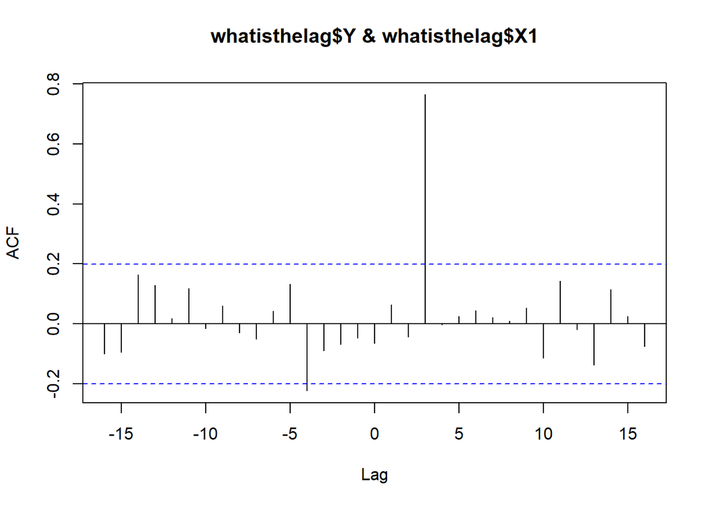

```r
#check for any corrrleation between Y and X1
ccf(whatisthelag$Y,whatisthelag$X1)
```

#### Vector AR(VAR)

**Simultaneously modeling several time series**

In the multiple regressions with correlated errors we did not take into account the possible correlation structure within and among the independent variables.

In this setting there is no distinction between dependent and independent variables. Our goal is to see how the interrelationships among the variables help with such things as forecasting one or more of the variables..

- First subscript is time
- Second subscript is variable number

### VAR

Bivariate VAR(1):

Two variables: $X_{t1}$ and $X_{t2}$ The value of $X_{t1}$ and $X_{t2}$ invlove lag one values $X_{t-1,1}$ and $X_{t-1,2}$

Bivariate VAR(2)

**Note that:**

- Clearly, writing the equations in expanded form will get very cumbersome very quickly for higher order models and more than two variables
- We use R functions!
- CRAN package **vars** is particularly useful

#### Forecasting with VAR Models

Forecasting with VAR(p) models is simply an extension of forecasting with AR(p) models

**Example:**

```r
x1.25=c( -1.03,  0.11, -0.18, 0.20, -0.99, -1.63, 1.07,  2.26, -0.49, -1.54,  0.45,  0.92,
         -0.05, -1.18,  0.90,  1.17,  0.31,  1.19,  0.27, -0.09,  0.23, -1.91,  0.46,  3.61, -0.03)
x2.25=c( -0.82,  0.54,  1.13, -0.24, -0.77,  0.22,  0.46, -0.03, -0.59,  0.45,  0.59,  0.15,
         0.60,  0.13, -0.04,  0.12, -0.96,  0.23,  1.81, -0.01, -0.95, -0.55, -0.15,  0.71,  0.90)
#only use 20 to fit that way we can use the last 5 to check our forcast
x1=x1.25[1:20]
x2=x2.25[1:20]
```

Recall a univarate forcast with the data above

```r
p1=aic.wge(x1,p=0:8,q=0:0)
# aic picks p=2
x1.est=est.ar.wge(x1,p=p1$p)
```

```
##
## Coefficients of Original polynomial:
## 0.1769 -0.5845
##
## Factor                 Roots                Abs Recip    System Freq
## 1-0.1769B+0.5845B^2    0.1513+-1.2993i      0.7645       0.2315
##
##
##
## Coefficients of Original polynomial:
## 0.1769 -0.5845
##
## Factor                 Roots                Abs Recip    System Freq
## 1-0.1769B+0.5845B^2    0.1513+-1.2993i      0.7645       0.2315
##
##
```

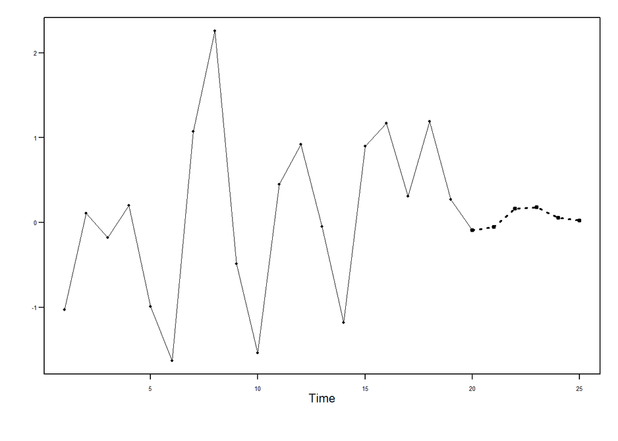

```
## $f
## [1] -0.05618801  0.16020033  0.17870817  0.05550939  0.02290354
##
## $ll
## [1] -1.604628 -1.412270 -1.611932 -1.762032 -1.848450
##
## $ul
## [1] 1.492252 1.732670 1.969348 1.873051 1.894257
##
## $resid
##  [1]  0.00000000  0.00000000 -0.91899171  0.17859031 -1.24811117 -1.45555314
##  [7]  0.66211878  1.00054452 -0.38185244 -0.24997797  0.31843556 -0.17720182
## [13] -0.06723369 -0.75098216  0.96193279  0.20362081  0.51156253  1.70146617
## [19]  0.12318933  0.44022982
##
## $wnv
## [1] 0.6241323
##
## $se
## [1] 0.7900204 0.8022806 0.9135919 0.9273170 0.9547724
##
## $psi
## [1]  0.1768573 -0.5531894 -0.2012030  0.2877372  0.1684851
```

```r
fore.arma.wge(x1,phi=x1.est$phi,n.ahead=5,lastn=FALSE,limits=FALSE)
```

```r
p2=aic.wge(x2,p=0:8,q=0:0)
# aic picks p=2
x2.est=est.ar.wge(x1,p=p2$p)
```

```
##
## Coefficients of Original polynomial:
## 0.1769 -0.5845
##
## Factor                 Roots                Abs Recip    System Freq
## 1-0.1769B+0.5845B^2    0.1513+-1.2993i      0.7645       0.2315
##
##
##
## Coefficients of Original polynomial:
## 0.1769 -0.5845
##
## Factor                 Roots                Abs Recip    System Freq
## 1-0.1769B+0.5845B^2    0.1513+-1.2993i      0.7645       0.2315
##
##
```

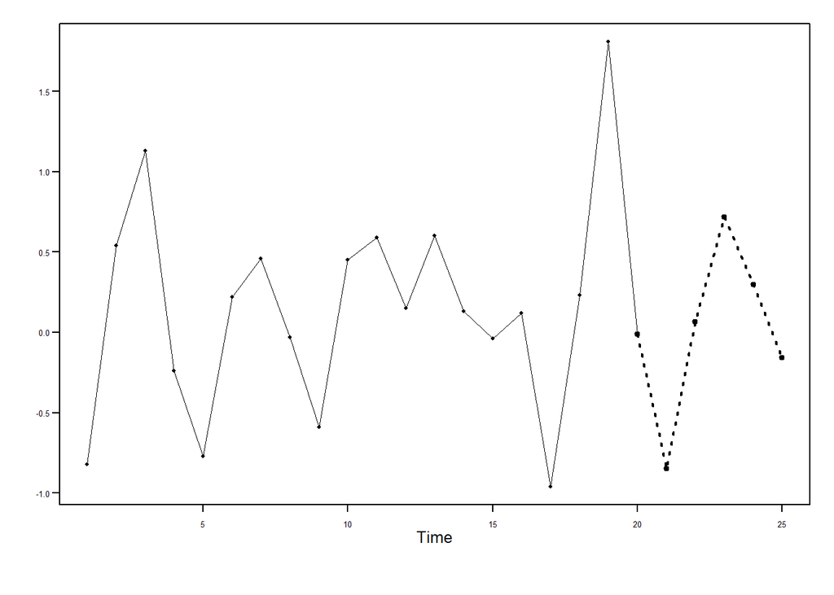

```
## $f
## [1] -0.85062527  0.06443552  0.71758921  0.29828059 -0.15762457
##
## $ll
## [1] -1.7765800 -0.8758889 -0.3531992 -0.7885945 -1.2766792
##
## $ul
## [1] 0.07532944 1.00475998 1.78837767 1.38515567 0.96143004
##
## $resid
##  [1]  0.000000000  0.000000000  0.346203207 -0.333266304 -0.276135697
##  [6]  0.006877695 -0.237979050 -0.191801608 -0.524869219  0.327781629
## [11] -0.043452019  0.099634551  0.709277284 -0.097474387  0.078659110
## [16] -0.005975047 -1.213631762  0.260889027  0.999203479 -0.404714339
##
## $wnv
## [1] 0.2231862
##
## $se
## [1] 0.4724259 0.4797574 0.5463206 0.5545281 0.5709462
##
## $psi
## [1]  0.1768573 -0.5531894 -0.2012030  0.2877372  0.1684851
```

```r
fore.arma.wge(x2,phi=x2.est$phi,n.ahead=5,lastn=FALSE,limits=FALSE)
```

Vector Autoregressive Models to use coralation to improve the forcast.

Using multivariet to forcast

```r
#install.packages("vars")
# VAR and VARselect are from CRAN package vars
X=cbind(x1,x2)
head(X)
```

```
##         x1    x2
## [1,] -1.03 -0.82
## [2,]  0.11  0.54
## [3,] -0.18  1.13
## [4,]  0.20 -0.24
## [5,] -0.99 -0.77
## [6,] -1.63  0.22
```

```r
VARselect(X, lag.max = 6, type = "const",season = NULL, exogen = NULL)
```

```
## $selection
## AIC(n)  HQ(n)  SC(n) FPE(n)
##      5      5      5      6
##
## $criteria
##                  1          2          3          4             5
## AIC(n) -0.25990814 -1.1581163 -1.4550375 -1.5858973 -9.2404995239
## HQ(n)  -0.28526090 -1.2003709 -1.5141939 -1.6619556 -9.3334596399
## SC(n)   0.01397358 -0.7016468 -0.8159801 -0.7642522 -8.2362665773
## FPE(n)  0.78159791  0.3354579  0.2842751  0.3311402  0.0002908131
##                                    6
## AIC(n)                           NaN
## HQ(n)                            NaN
## SC(n)                            NaN
## FPE(n) -0.00000000000000000001516079
```

```r
#VARselect picks p=5 (using AIC)
lsfit=VAR(X,p=5,type="const")
preds=predict(lsfit,n.ahead=5)
# preds$fcst$x1[1,1] - [5,1] are the VAR forecasts for x1.  Similar for x2
#this will list out just the forcast
preds$fcst$x1[1:5,1]
```

```
## [1]  0.230860065 -1.905108807  0.451961902  3.612474098 -0.009114912
```

**Concept check 12.4.4**

Using the code above from the VAR example:

Note that the VAR model results were stored in a variable named lsfit.  
Find the details of the model by entering summary(lsfit).  
There is strong evidence that the X1 variable is related to X2 variable but not at the current time period.

```r
summary(lsfit)
```

```
##
## VAR Estimation Results:
## =========================
## Endogenous variables: x1, x2
## Deterministic variables: const
## Sample size: 15
## Log Likelihood: 51.239
## Roots of the characteristic polynomial:
## 1.105 1.105 1.065 1.065 0.8517 0.8517 0.8413 0.8249 0.748 0.748
## Call:
## VAR(y = X, p = 5, type = "const")
##
##
## Estimation results for equation x1:
## ===================================
## x1 = x1.l1 + x2.l1 + x1.l2 + x2.l2 + x1.l3 + x2.l3 + x1.l4 + x2.l4 + x1.l5 + x2.l5 + const
##
##         Estimate Std. Error t value    Pr(>|t|)
## x1.l1 -0.0042949  0.0077157  -0.557       0.607
## x2.l1  0.0025313  0.0092102   0.275       0.797
## x1.l2  0.0040630  0.0081828   0.497       0.646
## x2.l2 -0.0077684  0.0103929  -0.747       0.496
## x1.l3 -0.0047742  0.0077547  -0.616       0.571
## x2.l3  0.0097459  0.0136252   0.715       0.514
## x1.l4  0.0044834  0.0053700   0.835       0.451
## x2.l4 -0.0079471  0.0140921  -0.564       0.603
## x1.l5 -0.0021468  0.0053796  -0.399       0.710
## x2.l5  2.0045969  0.0170018 117.905 0.000000031 ***
## const -0.0001567  0.0055712  -0.028       0.979
## ---
## Signif. codes:  0 '***' 0.001 '**' 0.01 '*' 0.05 '.' 0.1 ' ' 1
##
##
## Residual standard error: 0.01265 on 4 degrees of freedom
## Multiple R-Squared:     1,   Adjusted R-squared: 0.9999
## F-statistic: 1.055e+04 on 10 and 4 DF,  p-value: 0.00000002154
##
##
## Estimation results for equation x2:
## ===================================
```

[output cut: 16 more lines]

```
## Residual standard error: 0.5781 on 4 degrees of freedom
## Multiple R-Squared: 0.7415,  Adjusted R-squared: 0.09534
## F-statistic: 1.148 on 10 and 4 DF,  p-value: 0.4861
##
##
##
## Covariance matrix of residuals:
##         x1      x2
## x1 0.00016 0.00122
## x2 0.00122 0.33424
##
## Correlation matrix of residuals:
##        x1     x2
## x1 1.0000 0.1668
## x2 0.1668 1.0000
```

What lag of X2 is most associated with X1t? (Express your response as a whole number.)

**5**

What is the p-value that is reflecting the strength of that association? (Express your response rounded to nine decimal places.)

**.000000031**

#### Univariate Forecasts

What Happened?

Why are the forecasts for x1 so good?  
Let’s look at the data again.

x1(t) is essentially a scaled version of 2*x2(t-5)

```r
a = ccf(x2.25,x1.25)
```

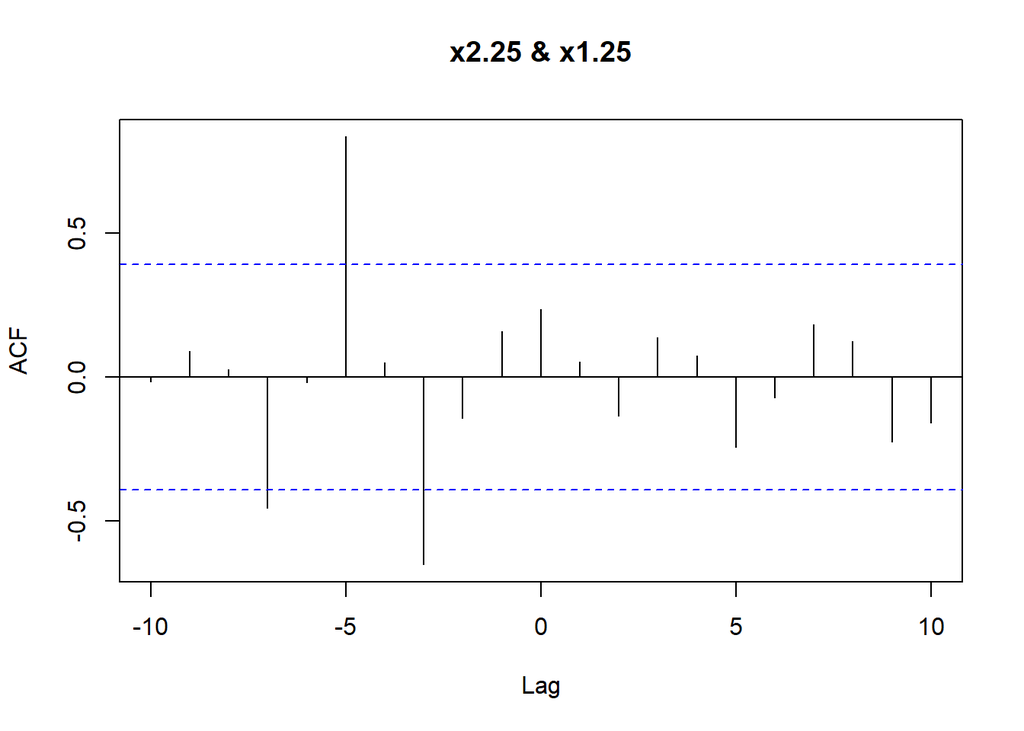

After running the R code for VAR modeling, if you type lsfit you obtain the following output:

```r
lsfit
```

```
##
## VAR Estimation Results:
## =======================
##
## Estimated coefficients for equation x1:
## =======================================
## Call:
## x1 = x1.l1 + x2.l1 + x1.l2 + x2.l2 + x1.l3 + x2.l3 + x1.l4 + x2.l4 + x1.l5 + x2.l5 + const
##
##         x1.l1         x2.l1         x1.l2         x2.l2         x1.l3
## -0.0042949121  0.0025312714  0.0040630246 -0.0077683607 -0.0047742378
##         x2.l3         x1.l4         x2.l4         x1.l5         x2.l5
##  0.0097458730  0.0044834024 -0.0079471196 -0.0021467602  2.0045968953
##         const
## -0.0001566637
##
##
## Estimated coefficients for equation x2:
## =======================================
## Call:
## x2 = x1.l1 + x2.l1 + x1.l2 + x2.l2 + x1.l3 + x2.l3 + x1.l4 + x2.l4 + x1.l5 + x2.l5 + const
##
##       x1.l1       x2.l1       x1.l2       x2.l2       x1.l3       x2.l3
## -0.19529163  0.07242205 -0.10080535 -0.84726636  0.35832020  0.30118975
##       x1.l4       x2.l4       x1.l5       x2.l5       const
## -0.01801003 -1.05778733  0.19452773  0.04821905  0.41631393
```

**Note:**

In the formula for $X_{t1}$, the coefficient of $X_{t-5,2}$ (**x2.l5**) is about **two** while all other coefficients are approximately zero.

Plot the forcast:

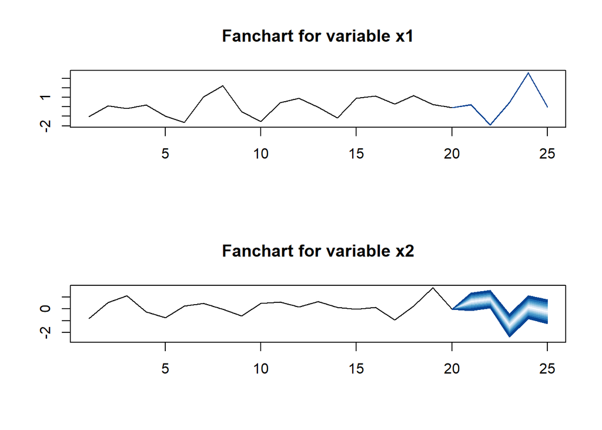

```r
library(RColorBrewer)
fanchart(preds, colors = brewer.pal(n = 8, name = "Blues")) # Change color pallet to make distinguishable.
```

**Note:** The margin or error for the x1 variable is so small that the forecasts and the upper and lower limits are nearly overlapped. We used the RColorBrewer package to change the colors to be more distinguishable.

**Comments about the Bivariate VAR(5) Example**

This example was constructed to show how one variable in a VAR model can be a leading indicator for another variable.

Because variable $X_{t1}=2X_{t-5,2}$, we would expect the VAR forecasts to somehow take advantage of this fact.  
**Notice that:**

- Both $X_{t1}$ and $X_{t2}$ were generated as AR(2) processes.
- AIC applied to each series separately picked an AR(2).
- Function **VARselect** identified the VAR model as a VAR(5).
  - It was necessary that **p** was at least **5** so that lag 5 would be in the fitted model
  - AIC detected this by itself
  - The fitted **VAR(5)** model gave essentially perfect forecasts for $X_{t1}$ for steps ahead to 5
  - The forcast for $X_{t2}$ showed no detectable improvement over the univariate forecasts.

#### 12.5 Melanoma and Sunspot Example

Melanoma Sunspot Example Annual Data: 1936-1972

This data set has caused interest because of the fact that there is some evidence that the melanoma incidence at year $t$ is related to the sunspot number at year $t-2$.

The peak at -2 suggests that sunspot number at time t-2 is related to melanoma at time t  
But, note that the peak is within the error bars for zero cross-correlations

- Relationship may not be strong

We know data out to t=1972  
We will perform analysis based on data only up to t=1967

```r
# melanoma incidence and sunspot numbers 1936-1972
 melanoma=c(1.0, 0.9, 0.8, 1.4, 1.2, 1.0, 1.5, 1.9, 1.5, 1.5, 1.5, 1.6, 1.8, 2.8, 2.5, 2.5, 2.4, 2.1, 1.9, 2.4, 2.4, 2.6, 2.6, 4.4, 4.2, 3.8, 3.4, 3.6, 4.1, 3.7, 4.2, 4.1, 4.1, 4.0, 5.2, 5.3, 5.3)
sunspot=c(40, 115, 100,  80,  60,  40,  23,  10,  10,  25,  75, 145, 130, 130,  80,  65,  20,  10,   5,  10, 60, 190, 180, 175, 120,  50,  35,  20,  10,  15,  30,  60, 105, 105, 105,  80,  65)
#We know data out to t=1972
#We will perform analysis based on data only up to t=1967
mel.67=melanoma[1:32]
sun.67=sunspot[1:32]
```

AIC and modeling

```r
# AIC to pic the model
p.mel=aic.wge(mel.67,p=0:8,q=0:0)
p.mel$p
```

```
## [1] 1
```

```r
# estimate
mel.est=est.ar.wge(mel.67,p=p.mel$p)
```

```
##
## Coefficients of Original polynomial:
## 0.9270
##
## Factor                 Roots                Abs Recip    System Freq
## 1-0.9270B              1.0788               0.9270       0.0000
##
##
##
## Coefficients of Original polynomial:
## 0.9270
##
## Factor                 Roots                Abs Recip    System Freq
## 1-0.9270B              1.0788               0.9270       0.0000
##
##
```

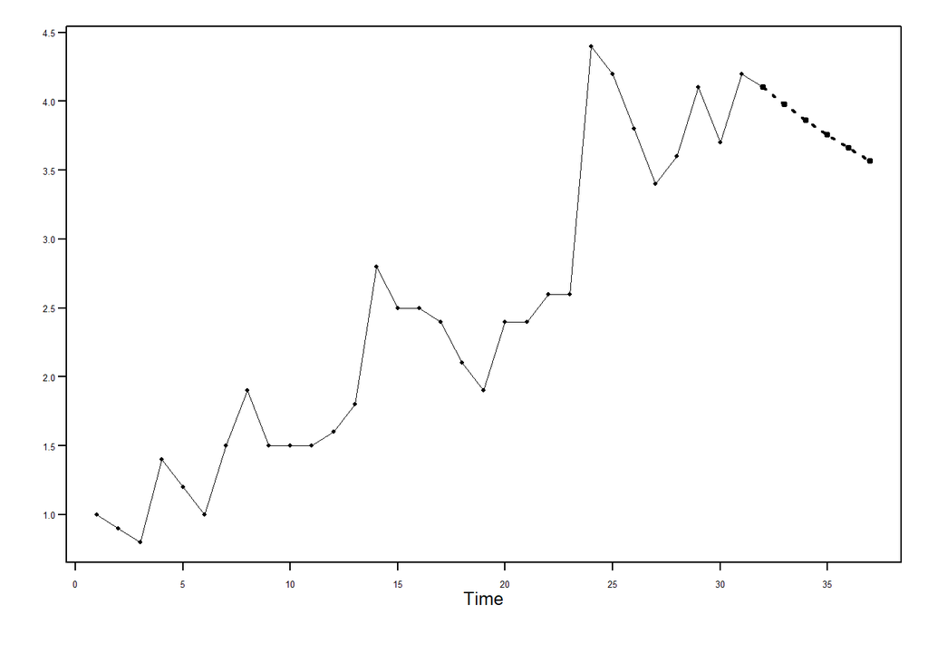

```
## $f
## [1] 3.977020 3.863019 3.757342 3.659380 3.568571
##
## $ll
## [1] 3.068753 2.624539 2.293449 2.026461 1.803287
##
## $ul
## [1] 4.885287 5.101499 5.221234 5.292300 5.333854
##
## $resid
##  [1]  0.000000000 -0.203357904 -0.210659125  0.482039654 -0.274153022
##  [6] -0.288755463  0.396642096  0.333148199 -0.437646919 -0.066851801
## [11] -0.066851801  0.033148199  0.140449419  0.955051861 -0.271935933
## [16]  0.006160405 -0.093839595 -0.301140816 -0.223044478  0.462353081
## [21] -0.001140816  0.198859184  0.013461626  1.813461626 -0.055116403
## [26] -0.269718844 -0.298923727  0.271871391  0.586473832 -0.277020065
## [31]  0.593775052  0.030281156
##
## $wnv
## [1] 0.214741
##
## $se
## [1] 0.4634015 0.6318775 0.7468839 0.8331222 0.9006548
##
## $psi
## [1] 0.9269878 0.8593064 0.7965665 0.7384074 0.6844947
```

```r
# forcast
fore.arma.wge(mel.67,phi=mel.est$phi,n.ahead=5,lastn=FALSE,limits=FALSE)
```

```r
# AIC to pic the model
p.sun=aic.wge(sun.67,p=0:8,q=0:0)
p.sun$p
```

```
## [1] 3
```

```r
# estimate
sun.est=est.ar.wge(sun.67,p=p.sun$p)
```

```
##
## Coefficients of Original polynomial:
## 0.9039 -0.0469 -0.4317
##
## Factor                 Roots                Abs Recip    System Freq
## 1-1.4361B+0.8112B^2    0.8851+-0.6702i      0.9007       0.1031
## 1+0.5322B             -1.8790               0.5322       0.5000
##
##
##
## Coefficients of Original polynomial:
## 0.9039 -0.0469 -0.4317
##
## Factor                 Roots                Abs Recip    System Freq
## 1-1.4361B+0.8112B^2    0.8851+-0.6702i      0.9007       0.1031
## 1+0.5322B             -1.8790               0.5322       0.5000
##
##
```

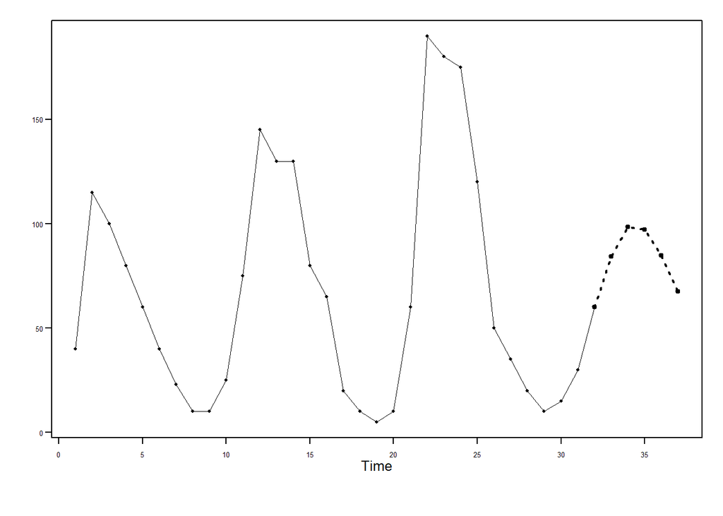

```
## $f
## [1] 84.39242 98.55759 97.26509 84.90076 67.66916
##
## $ll
## [1]  33.265437  29.638244  17.890005   4.718069 -13.339707
##
## $ul
## [1] 135.5194 167.4769 176.6402 165.0835 148.6780
##
## $resid
##  [1]   0.0000000   0.0000000   0.0000000 -25.7669992   3.9879989  -5.3479413
##  [7] -13.8425619 -21.0490122 -18.7304209 -11.6801307  19.1481517  44.6550627
## [13] -24.7980134  13.6336121  -6.8489349  16.8721856 -16.9155750  -8.5290063
## [19] -13.0778334 -23.4556228  17.4726093 100.3514581 -22.6555730   9.0726273
## [25]  14.2486524 -10.5865214  32.9492246   4.4772158 -22.8892342 -16.0299159
## [31] -12.4950551  -0.1368735
##
## $wnv
## [1] 680.4374
##
## $se
## [1] 26.08519 35.16293 40.49749 40.90954 41.33106
##
## $psi
## [1]  0.9039432  0.7701752  0.2220291 -0.2257138 -0.5469665
```

```r
# forcast
fore.arma.wge(sun.67,phi=sun.est$phi,n.ahead=5,lastn=FALSE,limits=FALSE)
```

VAR and VARselect are from CRAN package vars

```r
# VAR and VARselect are from CRAN package vars
X=cbind(mel.67,sun.67)
VARselect(X, lag.max = 6, type = "const",season = NULL, exogen = NULL) #AIC = 5.04
```

```
## $selection
## AIC(n)  HQ(n)  SC(n) FPE(n)
##      4      3      3      3
##
## $criteria
##                 1          2          3          4          5          6
## AIC(n)   5.985865   5.786983   5.064980   5.045436   5.275197   5.203824
## HQ(n)    6.069469   5.926324   5.260057   5.296250   5.581747   5.566111
## SC(n)    6.276195   6.270866   5.742416   5.916426   6.339740   6.461921
## FPE(n) 398.588572 329.205245 162.746521 164.858917 218.902164 221.638785
```

```r
#VARselect picks p=4 (using AIC)
lsfit=VAR(X,p=4,type='const')
preds=predict(lsfit,n.ahead=5)
#preds$fcst$mel[1,1]-[5,1] are the VAR forecasts formenlanoma.  Similar for sunspot.
```

Plot the forcast

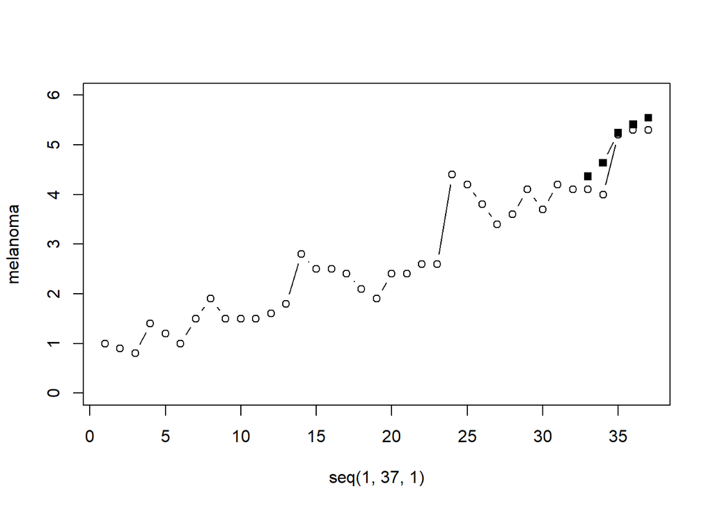

```r
plot(seq(1,37,1),melanoma, type = "b", ylim = c(0,6))
points(seq(33,37,1),preds$fcst$mel.67[1:5,1],type = "b", pch = 15)
```

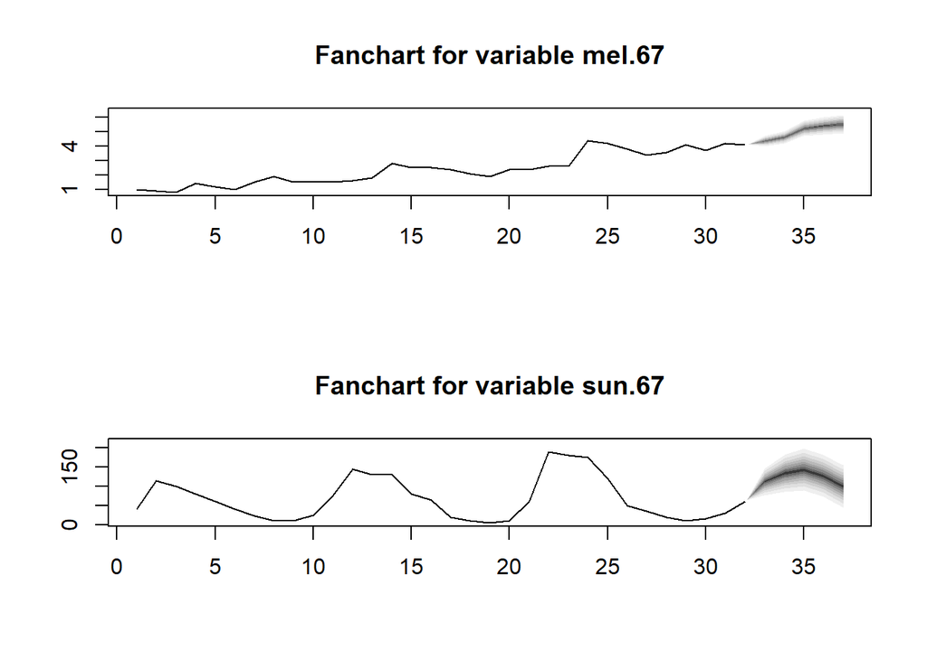

```r
fanchart(preds)
```

#### Melanoma incidence and sunspot numbers 1936-1972

```r
# Enter the data
melanoma=c(1.0, 0.9, 0.8, 1.4, 1.2, 1.0, 1.5, 1.9, 1.5, 1.5, 1.5, 1.6, 1.8, 2.8, 2.5, 2.5, 2.4, 2.1, 1.9, 2.4, 2.4, 2.6, 2.6, 4.4, 4.2, 3.8, 3.4, 3.6, 4.1, 3.7, 4.2, 4.1, 4.1, 4.0, 5.2, 5.3, 5.3)
sunspot=c(40, 115, 100,  80,  60,  40,  23,  10,  10,  25,  75, 145, 130, 130,  80,  65,  20,  10,   5,  10, 60, 190, 180, 175, 120,  50,  35,  20,  10,  15,  30,  60, 105, 105, 105,  80,  65)
```

Use the Cross Corralation Function to see a weak corralation (spike) at -2 and -12.

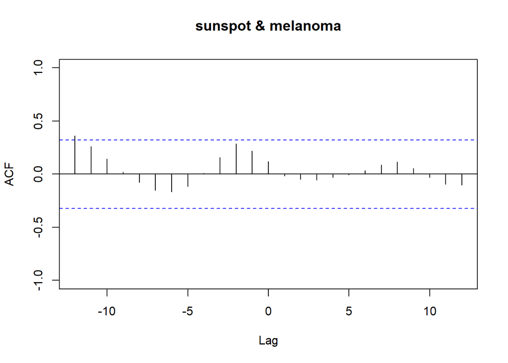

```r
#use the Cross Corralation Function
ccf(sunspot,melanoma, ylim=c(-1,1))
```

#### Univariate Regression

save some of the last data for testing the forcast

```r
#save some of the last data for testing the forcast
mel.67=melanoma[1:32]
sun.67=sunspot[1:32]
```

Diganose the AR side of the melanoma data model with AIC.

```r
p.mel=aic.wge(mel.67,p=0:8,q=0:0)
p.mel$p
```

```
## [1] 1
```

Estimate the coefficient and make an AR(1) forecast for the melanoma data. This will slowly dampen to the sample mean.

```r
mel.est=est.ar.wge(mel.67,p=p.mel$p)
```

```
##
## Coefficients of Original polynomial:
## 0.9270
##
## Factor                 Roots                Abs Recip    System Freq
## 1-0.9270B              1.0788               0.9270       0.0000
##
##
##
## Coefficients of Original polynomial:
## 0.9270
##
## Factor                 Roots                Abs Recip    System Freq
## 1-0.9270B              1.0788               0.9270       0.0000
##
##
```

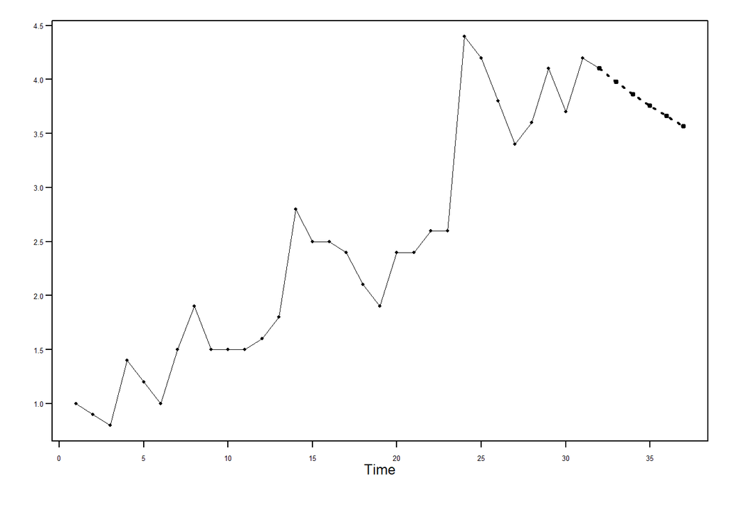

```
## $f
## [1] 3.977020 3.863019 3.757342 3.659380 3.568571
##
## $ll
## [1] 3.068753 2.624539 2.293449 2.026461 1.803287
##
## $ul
## [1] 4.885287 5.101499 5.221234 5.292300 5.333854
##
## $resid
##  [1]  0.000000000 -0.203357904 -0.210659125  0.482039654 -0.274153022
##  [6] -0.288755463  0.396642096  0.333148199 -0.437646919 -0.066851801
## [11] -0.066851801  0.033148199  0.140449419  0.955051861 -0.271935933
## [16]  0.006160405 -0.093839595 -0.301140816 -0.223044478  0.462353081
## [21] -0.001140816  0.198859184  0.013461626  1.813461626 -0.055116403
## [26] -0.269718844 -0.298923727  0.271871391  0.586473832 -0.277020065
## [31]  0.593775052  0.030281156
##
## $wnv
## [1] 0.214741
##
## $se
## [1] 0.4634015 0.6318775 0.7468839 0.8331222 0.9006548
##
## $psi
## [1] 0.9269878 0.8593064 0.7965665 0.7384074 0.6844947
```

```r
fore.arma.wge(mel.67,phi=mel.est$phi,n.ahead=5,lastn=FALSE,limits=FALSE)
```

Diganose the AR side of the sun data model with AIC.

```r
p.sun=aic.wge(sun.67,p=0:8,q=0:0)
p.sun$p
```

```
## [1] 3
```

Estimate the coefficient and make an AR(3) forecast for the sun data. This will slowly dampen to the sample mean.

```r
sun.est=est.ar.wge(sun.67,p=p.sun$p)
```

```
##
## Coefficients of Original polynomial:
## 0.9039 -0.0469 -0.4317
##
## Factor                 Roots                Abs Recip    System Freq
## 1-1.4361B+0.8112B^2    0.8851+-0.6702i      0.9007       0.1031
## 1+0.5322B             -1.8790               0.5322       0.5000
##
##
##
## Coefficients of Original polynomial:
## 0.9039 -0.0469 -0.4317
##
## Factor                 Roots                Abs Recip    System Freq
## 1-1.4361B+0.8112B^2    0.8851+-0.6702i      0.9007       0.1031
## 1+0.5322B             -1.8790               0.5322       0.5000
##
##
```

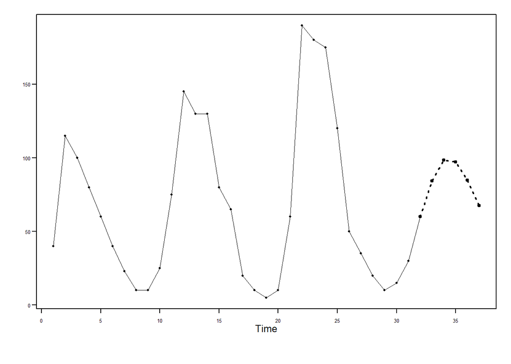

```
## $f
## [1] 84.39242 98.55759 97.26509 84.90076 67.66916
##
## $ll
## [1]  33.265437  29.638244  17.890005   4.718069 -13.339707
##
## $ul
## [1] 135.5194 167.4769 176.6402 165.0835 148.6780
##
## $resid
##  [1]   0.0000000   0.0000000   0.0000000 -25.7669992   3.9879989  -5.3479413
##  [7] -13.8425619 -21.0490122 -18.7304209 -11.6801307  19.1481517  44.6550627
## [13] -24.7980134  13.6336121  -6.8489349  16.8721856 -16.9155750  -8.5290063
## [19] -13.0778334 -23.4556228  17.4726093 100.3514581 -22.6555730   9.0726273
## [25]  14.2486524 -10.5865214  32.9492246   4.4772158 -22.8892342 -16.0299159
## [31] -12.4950551  -0.1368735
##
## $wnv
## [1] 680.4374
##
## $se
## [1] 26.08519 35.16293 40.49749 40.90954 41.33106
##
## $psi
## [1]  0.9039432  0.7701752  0.2220291 -0.2257138 -0.5469665
```

```r
fore.arma.wge(sun.67,phi=sun.est$phi,n.ahead=5,lastn=FALSE,limits=FALSE)
```

First step is to bind the two together with the **cbind** command.

```r
X=cbind(mel.67,sun.67)
```

Second, get a good estimate of k to see what the lag is.  
Look for the lowest AIC, in this case it is an AIC of 5.04.

```r
#VAR and VARselect are from CRAN package vars
VARselect(X, lag.max = 6, type = "const",season = NULL, exogen = NULL) #AIC = 5.04
```

```
## $selection
## AIC(n)  HQ(n)  SC(n) FPE(n)
##      4      3      3      3
##
## $criteria
##                 1          2          3          4          5          6
## AIC(n)   5.985865   5.786983   5.064980   5.045436   5.275197   5.203824
## HQ(n)    6.069469   5.926324   5.260057   5.296250   5.581747   5.566111
## SC(n)    6.276195   6.270866   5.742416   5.916426   6.339740   6.461921
## FPE(n) 398.588572 329.205245 162.746521 164.858917 218.902164 221.638785
```

VARselect picks p=4 (using AIC) so use that in VAR.

```r
lsfit=VAR(X,p=4,type='const')
```

Now look at the predictions by feeding the lsfit into the predict function.

```r
preds=predict(lsfit,n.ahead=5)
preds
```

```
## $mel.67
##          fcst    lower    upper        CI
## [1,] 4.364052 3.762310 4.965793 0.6017418
## [2,] 4.635511 3.930144 5.340878 0.7053674
## [3,] 5.241517 4.349345 6.133689 0.8921718
## [4,] 5.412168 4.440600 6.383736 0.9715679
## [5,] 5.544624 4.501463 6.587785 1.0431610
##
## $sun.67
##          fcst    lower    upper       CI
## [1,] 111.9755 54.73742 169.2135 57.23806
## [2,] 134.1595 56.87783 211.4411 77.28166
## [3,] 143.6726 58.01010 229.3352 85.66253
## [4,] 127.2407 41.06890 213.4125 86.17181
## [5,]  99.9504 12.01179 187.8890 87.93861
```

To get the melanoma forcast we will need to dig into the preds variable a bit. Rows 1 through 5 coloum 1 are the VAR forecasts for menlanoma. Similar for sunspot.

```r
preds$fcst$mel.67[1:5,1]
```

```
## [1] 4.364052 4.635511 5.241517 5.412168 5.544624
```

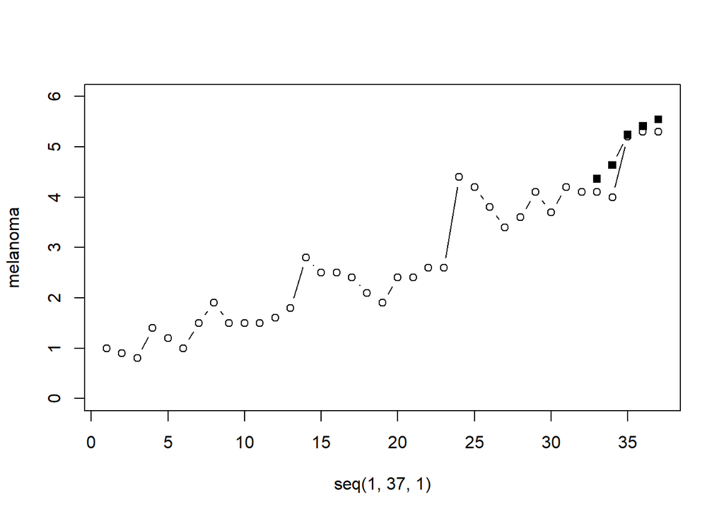

```r
#plot the original data from 1 to 37 with dot and lines "b"
plot(seq(1,37,1),melanoma, type = "b", ylim = c(0,6))
#Overlay the forcast with squares (pch = 15)
points(seq(33,37,1),preds$fcst$mel.67[1:5,1],type = "b", pch = 15)
```

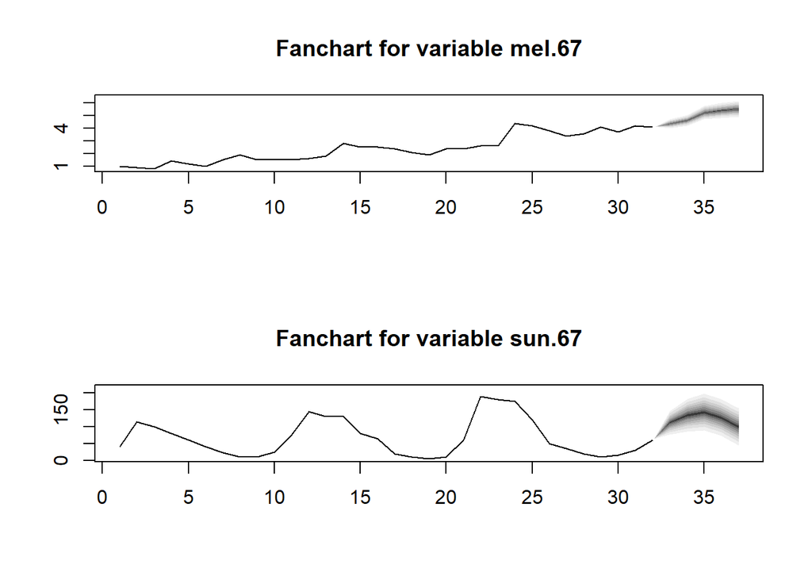

```r
fanchart(preds)
```

Again, judging by the wider confidence intervals, we can see that sunspots provide more information in predicting melanoma than the other way around.

Before leaving this example, we examine the melanoma-sunspot data using a multiple regression with correlated errors.

Since melanoma tends to trend upward we include t (time) and sunspot as independent variables for predicting melanoma.

```r
t=1:37 #the size of the dataset
#Fitting Linear Model using t (time) and sunspot as independent variables
ksfit=lm(melanoma~sunspot+t)
#Diganose with AIC using the residuals
phi=aic.wge(ksfit$residuals,p=0:8,q=0:0)
# AIC picks p=2
fit=arima(melanoma,order=c(phi$p,0,0),xreg=cbind(t,sunspot))
fit
```

```
##
## Call:
## arima(x = melanoma, order = c(phi$p, 0, 0), xreg = cbind(t, sunspot))
##
## Coefficients:
##          ar1      ar2  intercept       t  sunspot
##       0.4795  -0.2461     0.3957  0.1157   0.0021
## s.e.  0.1627   0.1713     0.1951  0.0077   0.0017
##
## sigma^2 estimated as 0.1424:  log likelihood = -16.59,  aic = 45.17
```

Devide by the **Standard Errors** to see if there is any significants

**There is a significant trend (0.1157/0.0077=15.02597) but sunspot is not a significant predictor (0.0021/0.0017=1.235294).**

Visualize the non lagged data from above. The aic is 45.17.

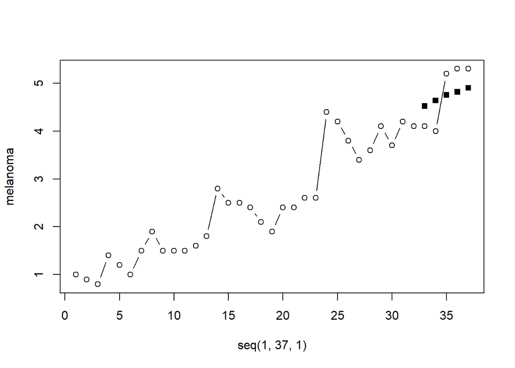

```r
preds = predict(fit,newxreg = data.frame(t = c(33,34,35,36,37), sunspot = sunspot[33:37]))
plot(seq(1,37,1),melanoma, type = "b")
points(seq(33,37,1),preds$pred,type = "b", pch = 15)
```

Remembering that melanoma incidence seemed to be related to sunspot activity two years earlier, we examine a lagged effect (along with time). We compute variables sun2 and mel2 below.

```r
t=1:35
sun2=sunspot[1:35]
mel2=melanoma[1:35]
for(i in 1:35){mel2[i]=melanoma[i+2]}
ksfit=lm(mel2~t+sun2)
phi=aic.wge(ksfit$residuals,p=0:8,q=0:0)  # AIC picks p=1
fit=arima(mel2,order=c(phi$p,0,0),xreg=cbind(t,sun2))
fit
```

```
##
## Call:
## arima(x = mel2, order = c(phi$p, 0, 0), xreg = cbind(t, sun2))
##
## Coefficients:
##          ar1  intercept       t    sun2
##       0.3124     0.2746  0.1177  0.0064
## s.e.  0.1732     0.1608  0.0068  0.0013
##
## sigma^2 estimated as 0.08449:  log likelihood = -6.47,  aic = 22.94
```

AIC picked an AR(1) for the residuals. The coefficients for **trend and sunspots** are significant in the lagged data.

The aic is 22.94 beating the 45.17 in the above non lagged model.

Visualize the lagged data.

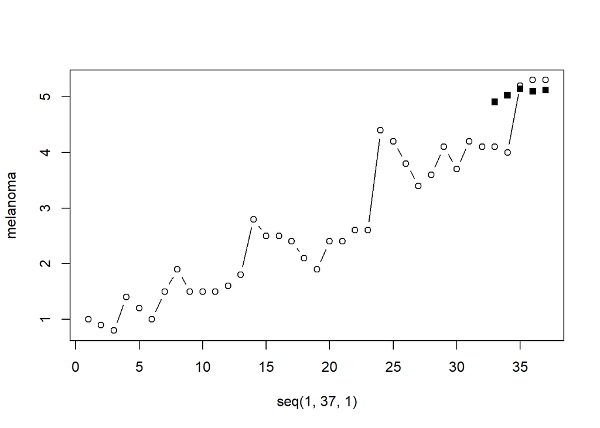

```r
preds = predict(fit,newxreg = data.frame(t = c(33,34,35,36,37), sunspot = sunspot[33:37]))
plot(seq(1,37,1),melanoma, type = "b")
points(seq(33,37,1),preds$pred,type = "b", pch = 15)
```

#### 12.5.2 Concept Check

Recall the sales example we worked with earlier from the attached sales data set (BusinessSales.csv). There we fit a multiple regression with serially correlated errors.

**You will use this data to complete this and the next three Concept Check questions.**

If you recall, the model with the time trend and the TV and online advertising variables at lag 1 had an AIC of 352. We would like to compare a VAR model to the previous model based on the AIC.

Step 1: Reload the data in BusinessSales.csv.  
*(Start with a fresh data set. You don’t need to have the lagged variables in the data set when doing VAR. It will search for those automatically.)* Drop the first coloum, removing what is essentially the ‘t’.

```r
#Drop the first coloum
BSales <- read.csv("businesssales.csv", header = TRUE)[2:5]
```

Step 2: Use VARselect() to estimate the order of the VAR model. Use the BIC, which is noted as “SC(n).”

```r
VARselect(BSales, lag.max = 6, type = "const",season = NULL, exogen = NULL)
```

```
## $selection
## AIC(n)  HQ(n)  SC(n) FPE(n)
##      3      2      2      3
##
## $criteria
##                   1             2             3             4             5
## AIC(n) -5.916368500 -7.4683110409 -7.6414595787 -7.5328969475 -7.3144759165
## HQ(n)  -5.697792980 -7.0748751050 -7.0731632269 -6.7897401797 -6.3964587328
## SC(n)  -5.375241951 -6.4942832519 -6.2345305502 -5.6930666794 -5.0417444089
## FPE(n)  0.002696053  0.0005722369  0.0004835655  0.0005438667  0.0006865584
##                    6
## AIC(n) -7.2023431278
## HQ(n)  -6.1094655282
## SC(n)  -4.4967103807
## FPE(n)  0.0007849153
```

What is the order estimated by VARSelect? (Express your response as a whole number.)  
**SC(n) = 2**

#### 12.5.3 Concept Check

Step 3: Use VAR() and the order estimated in the last step to fit the VAR model. Fit it with a trend and without a trend.

```r
#Fit it with a trend
Trend=VAR(BSales, p = 2, type = 'trend')
summary(Trend)
```

```
##
## VAR Estimation Results:
## =========================
## Endogenous variables: sales, ad_tv, ad_online, discount
## Deterministic variables: trend
## Sample size: 98
## Log Likelihood: -180.378
## Roots of the characteristic polynomial:
## 0.998 0.9291 0.9291 0.8147 0.6598 0.6598 0.1925 0.1925
## Call:
## VAR(y = BSales, p = 2, type = "trend")
##
##
## Estimation results for equation sales:
## ======================================
## sales = sales.l1 + ad_tv.l1 + ad_online.l1 + discount.l1 + sales.l2 + ad_tv.l2 + ad_online.l2 + discount.l2 + trend
##
##                Estimate Std. Error t value       Pr(>|t|)
## sales.l1      0.0915900  0.1433848   0.639         0.5246
## ad_tv.l1      2.8985226  0.5310755   5.458 0.000000430138 ***
## ad_online.l1  5.6516921  0.8013034   7.053 0.000000000363 ***
## discount.l1   0.0540125  0.1195890   0.452         0.6526
## sales.l2     -0.1381003  0.0602733  -2.291         0.0243 *
## ad_tv.l2      0.5872553  0.6048463   0.971         0.3342
## ad_online.l2  4.3159282  0.8862655   4.870 0.000004817349 ***
## discount.l2  -0.1046041  0.1213704  -0.862         0.3911
## trend        -0.0003325  0.0047046  -0.071         0.9438
## ---
## Signif. codes:  0 '***' 0.001 '**' 0.01 '*' 0.05 '.' 0.1 ' ' 1
##
##
## Residual standard error: 1.153 on 89 degrees of freedom
## Multiple R-Squared: 0.9996,  Adjusted R-squared: 0.9996
## F-statistic: 2.43e+04 on 9 and 89 DF,  p-value: < 0.00000000000000022
##
##
## Estimation results for equation ad_tv:
## ======================================
## ad_tv = sales.l1 + ad_tv.l1 + ad_online.l1 + discount.l1 + sales.l2 + ad_tv.l2 + ad_online.l2 + discount.l2 + trend
##
```

[output cut: 64 more lines]

```
##
##
## Covariance matrix of residuals:
##             sales    ad_tv ad_online discount
## sales     1.32917 0.258425  0.259699 0.055587
## ad_tv     0.25843 0.110704  0.068881 0.005965
## ad_online 0.25970 0.068881  0.078500 0.009838
## discount  0.05559 0.005965  0.009838 0.387417
##
## Correlation matrix of residuals:
##             sales  ad_tv ad_online discount
## sales     1.00000 0.6737   0.80398  0.07746
## ad_tv     0.67369 1.0000   0.73890  0.02880
## ad_online 0.80398 0.7389   1.00000  0.05641
## discount  0.07746 0.0288   0.05641  1.00000
```

```r
#Fit it without a trend
NoTrend =VAR(BSales,p=2,type='const')
summary(NoTrend)
```

```
##
## VAR Estimation Results:
## =========================
## Endogenous variables: sales, ad_tv, ad_online, discount
## Deterministic variables: const
## Sample size: 98
## Log Likelihood: -160.657
## Roots of the characteristic polynomial:
## 0.9291 0.9291 0.8296 0.8296 0.8272 0.2824 0.2824 0.2571
## Call:
## VAR(y = BSales, p = 2, type = "const")
##
##
## Estimation results for equation sales:
## ======================================
## sales = sales.l1 + ad_tv.l1 + ad_online.l1 + discount.l1 + sales.l2 + ad_tv.l2 + ad_online.l2 + discount.l2 + const
##
##              Estimate Std. Error t value      Pr(>|t|)
## sales.l1      0.29570    0.12851   2.301        0.0237 *
## ad_tv.l1      2.08983    0.47861   4.366 0.00003399314 ***
## ad_online.l1  4.55729    0.71557   6.369 0.00000000815 ***
## discount.l1   0.04530    0.10280   0.441        0.6605
## sales.l2     -0.33491    0.06227  -5.379 0.00000060026 ***
## ad_tv.l2      0.48468    0.52009   0.932        0.3539
## ad_online.l2  3.53561    0.77417   4.567 0.00001582429 ***
## discount.l2  -0.14918    0.10418  -1.432        0.1557
## const        11.84587    2.11269   5.607 0.00000022849 ***
## ---
## Signif. codes:  0 '***' 0.001 '**' 0.01 '*' 0.05 '.' 0.1 ' ' 1
##
##
## Residual standard error: 0.9914 on 89 degrees of freedom
## Multiple R-Squared: 0.9256,  Adjusted R-squared: 0.9189
## F-statistic: 138.5 on 8 and 89 DF,  p-value: < 0.00000000000000022
##
##
## Estimation results for equation ad_tv:
## ======================================
## ad_tv = sales.l1 + ad_tv.l1 + ad_online.l1 + discount.l1 + sales.l2 + ad_tv.l2 + ad_online.l2 + discount.l2 + const
##
```

[output cut: 64 more lines]

```
##
##
## Covariance matrix of residuals:
##             sales     ad_tv ad_online  discount
## sales     0.98284  0.159504  0.170059  0.014471
## ad_tv     0.15950  0.082474  0.043248 -0.005636
## ad_online 0.17006  0.043248  0.055337 -0.000984
## discount  0.01447 -0.005636 -0.000984  0.383382
##
## Correlation matrix of residuals:
##             sales    ad_tv ad_online  discount
## sales     1.00000  0.56024  0.729206  0.023574
## ad_tv     0.56024  1.00000  0.640174 -0.031695
## ad_online 0.72921  0.64017  1.000000 -0.006756
## discount  0.02357 -0.03169 -0.006756  1.000000
```

Is there enough evidence to suggest the trend term is appropriate?

**No**

What is the AIC of the VAR model with no trend and the estimated order? (Express your answer rounded to two decimal places.)

```r
AIC(NoTrend)
```

```
## [1] 393.3132
```